# Getting Something for Nothing

## RustConf 2018

James Munns

@bitshiftmask

james.munns@ferrous-systems.com

[figure not shown]

## Rust? for Embedded?

> embedded rust isn’t a new idea

[figure not shown]

## Rust in 2018

> stabilizing things behind the scenes

## LLVM

> if they can do it, so can we!

`#![no_std]`

> where we’re going, we don’t need operating systems

```
$ rustup default stable
$ cargo build --target thumbv7em-none-eabihf
```

> building firmware doesn’t have to be complex

> batteries included

## Embedded Systems

> computers you don’t sit in front of

## Microcontrollers

> phenomenal hardware powers

> itty bitty living space

[figure not shown]

## Peripherals

> connecting your CPU to the physical world

## Hardware API

> herding bits

## Memory Mapped Peripherals

> `0x2000_0000` is a real place

> `0x0000_0000` is too

[figure not shown]

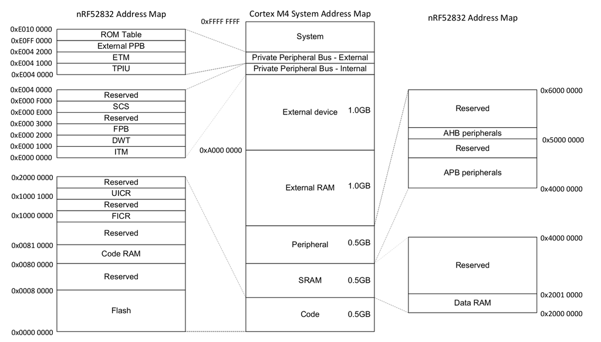

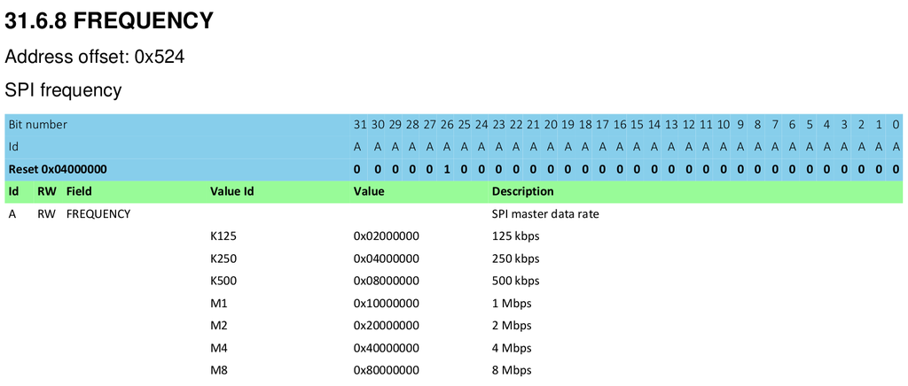

## Now what?

> write code!

```rust
use core::ptr;
const SER_PORT_SPEED_REG: *mut u32 = 0x4000_1000 as _;

fn read_serial_port_speed() -> u32 {
    unsafe { // <-- :(
        ptr::read_volatile(SER_PORT_SPEED_REG)
    }
}
fn write_serial_port_speed(val: u32) {
    unsafe { // <-- :(
        ptr::write_volatile(SER_PORT_SPEED_REG, val);
    }
}
```

```rust
use core::ptr;

struct SerialPort;

impl SerialPort {
    const SER_PORT_SPEED_REG: *mut u32 = 0x4000_1000 as _;
    pub const SER_PORT_SPEED_HI: u32 = 0x8000_0000;
    pub const SER_PORT_SPEED_LO: u32 = 0x0800_0000;

    fn new() -> SerialPort {
        SerialPort
    }
```

```rust
fn read_speed(&self) -> u32 {
    unsafe {
        ptr::read_volatile(Self::SER_PORT_SPEED_REG)
    }
}

fn write_speed(&mut self, val: u32) {
    unsafe {
        ptr::write_volatile(Self::SER_PORT_SPEED_REG, val);
    }
}
```

```rust
fn do_something() {
    let mut serial = SerialPort::new();

    let speed = serial.read_speed();
    // Do some work
    serial.write_speed(speed * 2);
}
```

```rust
fn do_something() {
    let mut serial = SerialPort::new();
    let speed = serial.read_speed();

    // Be careful, we have to go slow!
    if speed != SerialPort::SER_PORT_SPEED_LO {
        serial.write_speed(SerialPort::SER_PORT_SPEED_LO)
    }
    // First, send some pre-data
    something_else();
    // Okay, lets send some slow data
    // ...
}
```

```rust
fn something_else() {
    let mut serial = SerialPort::new();
    // We gotta go fast for this!
    serial.write_speed(SerialPort::SER_PORT_SPEED_HI);
    // send some data...
}
```

## This smells like mutable global state

> hardware is basically nothing but mutable global state

## What are our rules?

We should be able to share any number of read-only accesses to these peripherals

If something has read-write access to a peripheral, it should be the only reference

# Part I: The Borrow Checker

> ownership and borrows

## Singletons

> In software engineering, the singleton pattern is a software design pattern that restricts the instantiation of a class to one object.

https://en.wikipedia.org/wiki/Singleton_pattern

```rust
static mut THE_SERIAL_PORT: SerialPort = SerialPort;

fn main() {
    let _ = unsafe {
        THE_SERIAL_PORT.read_speed();
    }
}
```

> close, but not quite there

```rust
struct Peripherals {
    serial: Option<SerialPort>,
}
impl Peripherals {
    fn take_serial(&mut self) -> SerialPort {
        let p = replace(&mut self.serial, None);
        p.unwrap()
    }
}
static mut PERIPHERALS: Peripherals = Peripherals {
    serial: Some(SerialPort),
};
```

> take what you need, but only once

```rust
fn main() {
    let serial_1 = unsafe { PERIPHERALS.take_serial() };
    // This panics!
    // let serial_2 = unsafe { PERIPHERALS.take_serial() };
}
```

> small runtime overhead, big impact

```rust
#[macro_use(singleton)]
extern crate cortex_m;

fn main() {
    // OK if `main` is executed only once
    let x: &'static mut bool =
        singleton!(: bool = false).unwrap();
}
```

[cortex_m docs](https://docs.rs/cortex-m/0.5.2/cortex_m/macro.singleton.html)

```rust
// cortex-m-rtfm v0.3.x
app! {
    resources: {
        static RX: Rx<USART1>;
        static TX: Tx<USART1>;
    }
}
fn init(p: init::Peripherals) -> init::LateResources {
    // Note that this is now an owned value, not a reference
    let usart1: USART1 = p.device.USART1;
}
```

[japaric.io rtfm v3](https://blog.japaric.io/rtfm-v3/)

## But why?

> how do singletons make a difference?

```rust
impl SerialPort {
    const SER_PORT_SPEED_REG: *mut u32 = 0x4000_1000 as _;

    fn read_speed(
        &self // <------ This is really, really important
    ) -> u32 {
        unsafe {
            ptr::read_volatile(Self::SER_PORT_SPEED_REG)
        }
    }
}
```

```rust
fn main() {
    let serial_1 = unsafe { PERIPHERALS.take_serial() };

    // you can only read what you have access to
    let _ = serial_1.read_speed();
}
```

This is allowed to change hardware settings:

```rust
fn setup_spi_port(
    spi: &mut SpiPort,
    cs_pin: &mut GpioPin
) -> Result<()> {
    // ...
}
```

This isn’t:

```rust
fn read_button(gpio: &GpioPin) -> bool {
    // ...
}
```

> enforce whether code should or should not make changes to hardware

> at **compile time***

*: only works across one application, but for bare metal systems, we usually only have one anyway

## Before you worry

> you don’t have to write all of that code

> this is **rust**. there’s a tool for that

> it’s called svd2rust, and it turns XML files into rust code. like bindgen, but for hardware

## Now that peripherals are structs…

> what else can we do with Rust now?

# Part II: The Type System

> putting those strong types to work

## GPIOs

> take things one bit (of input or output) at a time

```rust
struct GpioPin; struct InputGpio; struct OutputGpio;

impl GpioPin {
    fn into_input(self) -> InputGpio {
        self.set_input_mode();
        InputGpio
    }
    fn into_output(self) -> OutputGpio {
        self.set_output_mode();
        OutputGpio
    }
}
```

```rust
impl LedPin {
    fn new(pin: OutputGpio) -> Self { ... }
    fn toggle(&mut self) -> bool { ... }
}

fn main() {
    let gpio_1 = unsafe { PERIPHERALS.take_gpio_1() };
    // This won't work, the types are wrong!
    // let led_1 = LedPin::new(gpio_1);
    let mut led_1 = LedPin::new(gpio_1.into_output());
    let _ = led_1.toggle();
}
```

## Enforce design contracts

> entirely at compile time

> no runtime cost

> no room for human error

## “no runtime cost”?

```rust
use core::mem::size_of;

let _ = size_of::<GpioPin>();     // == 0
let _ = size_of::<InputGpio>();   // == 0
let _ = size_of::<OutputGpio>();  // == 0
let _ = size_of::<()>();          // == 0
```

## Zero Sized Types

```rust
struct GpioPin;
```

> acts real at compile time

> doesn’t exist in the binary

> no RAM, no CPU, no space

## Can we do more with types?

> oh, you bet we can

## What if our `OutputGpio` has multiple modes?

> (it does)

```rust
pub struct PushPull;  // good for general usage
pub struct OpenDrain; // better for high power LEDs

pub struct OutputGpio<MODE> {
    _mode: MODE
}

impl<MODE> OutputGpio<MODE> {
    fn default() -> OutputGpio<OpenDrain> { ... }
    fn into_push_pull(self) -> OutputGpio<PushPull> { ... }
    fn into_open_drain(self) -> OutputGpio<OpenDrain> { ... }
}
```

```rust
/// This kind of LED only works with OpenDrain settings
struct DrainLed {
    pin: OutputGpio<OpenDrain>,
}

impl DrainLed {
    fn new(pin: OutputGpio<OpenDrain>) -> Self { ... }
    fn toggle(&self) -> bool { ... }
}
```

```rust
/// This kind of LED works with any output
struct LedDriver<MODE> {
    pin: OutputGpio<MODE>,
}

/// Generically support any OutputGpio variant!
impl<MODE> LedDriver<MODE> {
    fn new(pin: OutputGpio<MODE>) -> LedDriver<MODE> { ... }
    fn toggle(&self) -> bool { ... }
}
```